# Multiclass Classification pada Aktor Tweet: LSTM

Samuel Gema DV

24-01-2022

# Tentang Artikel

Artikel ini merupakan salah satu bagian dari *supervised machine learning workflow* yang akan diterapkan pada dashboard “AKSATA”; Sebuah dashboard yang didesain untuk melakukan Social Network Analysis dan Sentiment Analysis. Artikel ini akan membahas langkah-langkah menyiapkan model text classification, yang mana merupakan dasar dari sentiment analysis.  
Pada umumnya mungkin kita sering melihat berbagai *report* sentiment analysis yang mengklasifikasi setiap kalimat/frasa berdasarkan kategori: (1) Positif, (2) Netral, (3) Negatif.

Secara khusus untuk project AKSATA, saya ingin memberi label kategori tersebut berdasarkan aktor yang paling sering memenuhi suatu topik di jejaring sosial Twitter, yakni: (1) Personal, (2) Buzzer, (3) Media.

Tujuan dari pembedaan diatas adalah, saya ingin agar pengguna dashboard dapat diyakinkan, bahwa suatu trending topic tidak selalu tercipta atas respon kolektif para pengguna twitter. Dapat saja suatu topik menjadi trending karena aktivitas yang terorganisir (buzzer).

## Tentang Dataset

Dataset saya dapatkan dari API Twitter, dengan beberapa query yang didominasi oleh Buzzer seperti #Wadas_melawan, #Lurah_ham, #PecatYaqut, dsb; beberapa query yang didominasi oleh Personal seperti “quweenjojo”, “Pak Marsani”, dsb; dan beberapa tweet dari akun media seperti CNN Indonesia, Tribun (daerah), Tempo.

# Workflow 1: To Wordcloud, Exploratory Data Analysis

## Memuat Data

```r
aksata_data <- readRDS("for_model.rds")
```

```r
str(aksata_data)
```

```
#> Classes 'tbl_df', 'tbl' and 'data.frame':    15000 obs. of  2 variables:
#>  $ full_text: chr  "CS: Pastiian HPnya masih ada pulsa ya Pak.\n\nOrang kaya beneran✅:\nTenang mba, pascabayar kok\n\nOrang "| __truncated__ "Mau hp lo iPhone berlapis emas juga kalau gak ada pulsa ya gak bisa masuk kode OTP. Bener kata costumer service"| __truncated__ "@jaydiristui @DRespati3 \"…
#>  $ Label    : chr  "Personal" "Personal" "Personal" "Personal" ...
```

## Mengganti Label “Personal”, “Media”, “Buzzer” dengan angka

```r
library(dplyr)

# Normalize
aksata_enc <- aksata_data %>%
  mutate(Label = as.factor(Label)) %>%
  mutate(Label = as.integer(Label)-1)


aksata_enc[10001,]
```

| full_text | Label |
| --- | --- |
| Akustik Lagu Sunda Dalam Rangka Menghibur Anak Yatim, Kolaborasi antara ... https://t.co/BdFhd1Pu9F via @YouTube | 1 |

```r
aksata_enc[1,]
```

| full_text | Label |
| --- | --- |
| CS: Pastiian HPnya masih ada pulsa ya Pak.\n\nOrang kaya beneran:\nTenang mba, pascabayar kok\n\nOrang kaya jadi2an:\n*ngamuk di twitter sambil pamer harta* https://t.co/U46xI8jnQV | 2 |

- Kelas nomor 1: Media
- Kelas nomor 2: Personal
- Kelas nomor 0: Buzzer

## Load Library

```r
library(tidyverse)
library(katadasaR)
library(tm)
library(stringr)
```

## Subsetting + Cleansing tweet Buzzer

```r
# Menghapus pattern mention

buzzer <- aksata_enc %>%
  group_by(Label) %>%
  filter(Label == 0) %>%
  mutate(full_text = str_replace_all(
    string = full_text,
    pattern = "^@[A-Za-z]+|.+ @[A-Za-z]+",
    replacement = ""
  )) %>%
    mutate(full_text = str_replace_all(
    string = full_text,
    pattern = "@([^@ ]+){5,}",
    replacement = ""
  )) %>%
    mutate(full_text = str_replace_all(
    string = full_text,
    pattern = "^([^@]*@){5,}[^@]*$",
    replacement = ""))
```

```r
chr_buzzer <- as.character(buzzer$full_text)
```

### Data preprocessing untuk wordcloud

```r
library(rtweet)
library(textclean)

chr_buzzer <- replace_emoji(chr_buzzer)
chr_buzzer <- gsub( ","," ", chr_buzzer)
chr_buzzer <- gsub( "/n"," ", chr_buzzer)
chr_buzzer <- gsub( "#wadasmelawan"," ", chr_buzzer)
chr_buzzer <- gsub( "#usutwadas"," ", chr_buzzer)
chr_buzzer <- replace_hash(chr_buzzer)
chr_buzzer <- replace_html(chr_buzzer, symbol = FALSE)
# chr_buzzer <- replace_incomplete(chr_buzzer, replacement = "")
chr_buzzer <- replace_number(chr_buzzer, remove = TRUE)
chr_buzzer <- replace_url(chr_buzzer, replacement = "")
chr_buzzer <- tolower(chr_buzzer)
chr_buzzer <- removePunctuation(chr_buzzer)
#later: replace internet slang

chr_buzzer[100:110]
```

```
#>  [1] " akhir nya kebobrokan rezim terkuak  "
#>  [2] "  "
#>  [3] " mah kan "
#>  [4] " sikap muhammadiyah layak diacungi jempol  peka terhadap permasalahan sosial   kemanusiaan  "
#>  [5] "  "
#>  [6] "menurut catatan greenpeace indonesia  penambangan batu andesit di wadas ini akan mengancam ekosistem alam di desa wadas   "
#>  [7] "wadas  adalah bukti kongkrit  betapa pemimpin pencitraan tidak melulu memikirkan rakyat mereka hanya berbusa saat kampanye  tapi tak menganggap rakyat setelah berkuasa  "
#>  [8] "selamat pagi gaesss  lebih percaya mana nih  leterangan warga atau keterangan penguasa    "
#>  [9] "semakin aneh    "
#> [10] "musang berbulu ayam   "
#> [11] "sebelum daerah   lain akan seperti desa wadas maka bersatulah dan  dan kawan   mari support  "
```

Cleansing membuat banyak tweet bernilai NA. mencari alternatif lain

```r
buzzer2 <- aksata_enc %>%
  group_by(Label) %>%
  filter(Label == 0)
```

## Raw data “Buzzer”

```r
tes <- as.character(buzzer2$full_text)

# tes <- textclean::replace_number(tes, remove = TRUE)

# tes <- str_squish(tes)

str(tes)
```

```
#>  chr [1:5000] "Catet...😌\n\n#UsutWadas \n#UsutWadas\n\nhttps://t.co/tCcxb3qEi1" ...
```

```r
tes[1:10]
```

```
#>  [1] "Catet...😌\n\n#UsutWadas \n#UsutWadas\n\nhttps://t.co/tCcxb3qEi1"
#>  [2] "Tolong permintaan warga @Wadas_Melawan mengenai pencabutan IPL pertambangannya dilaksanakan ya,pak.. @ganjarpranowo \n\n#Wadas\n#FaktaWadas #UsutWadas # https://t.co/N7O3HjilOB"
#>  [3] "Proyek oligarki meminjam tangan penguasaan, telah merampas hak rakyat. BPN 'menjadi martir' Proyek Pembangunan Waduk Bener .\n#UsutWadas  \n#UsutWadas\nhttps://t.co/m2kbWnYPw6"
#>  [4] "Kau siapkan karpet merah para pemburu rente yang bergentayangan. Kau mudahkan dan kau buka lebar semua jalan, bahkan hak hidup pekerja pun kau abaikan.\n#UsutWadas \n#UsutWadas https://t.co/UYcQzjz6NW"
#>  [5] "Ketakutan yg kau tebarkan, intimidasi yg kau hujamkan pada setiap mereka yg berseberangan menjadi berbalik bak senjata makan tuan. Kekesalan,kesakitan, rasa diremehkan, disepelekan,dilupakan dan dihinakan, menggumpal-mengkristal meneguhkan satu kata LAWAN!\n#UsutWadas \n#UsutWadas https://t…
#>  [6] "Ya Allah...\n\n#UsutWadas \n#UsutWadas https://t.co/hONX6MMTQG"
#>  [7] "Ada bau busuk..\n\n#UsutWadas \n#UsutWadas https://t.co/zZSI0xwPJS"
#>  [8] "Fadli Zon: Sebenarnya pembangunan ini untuk siapa.?\n\n#UsutWadas \n#UsutWadas https://t.co/L3AVRXfoam"
#>  [9] "Ansor Banser menuntut 4 hal kepada presiden Joko Widodo dan gubernur Jawa Tengah Ganjar Pranowo untuk Warga Wadas Purworejo.\n@AlissaWahid\n@GUSDURians\n\nHidup NU !!!\nHidup Rakyat Indonesia !!!\nHidup Warga Wadas !!!\n\n#SaveWadas\n#WadasMelawan\n#UsutWadas\n#WadasMeradang https://t.co/Ft…
#> [10] "Hanya Terjadi Di 62..\nRakyat Pemilik Sah Atas Tanah Diusir Dengan Dengan Cara Cara Yang Tidak Berprikemanusiaan \n\n#UsutWadas\n#UsutWadas https://t.co/ZeJZWCatIo"
```

## Cleansing: Buzzer

```r
library(rtweet)
tes <- replace_emoji(tes) # replace emoji
tes <- replace_hash(tes) # replace hashtags
tes <- replace_html(tes, symbol = FALSE) # replace HTML Markups
tes <- replace_number(tes, remove = TRUE) # replace number
tes <- replace_url(tes, replacement = " ") # replace all http tag

tes <- gsub( ":"," ", tes)
tes <- gsub( "\n"," ", tes)
tes <- gsub( "^@[A-Za-z]+|.+ @[A-Za-z]+" ," ", tes)
tes <- gsub( "@([^@ ]+){5,}" ," ", tes)
tes <- gsub( "^([^@]*@){5,}[^@]*$" ," ", tes)
tes <- removePunctuation(tes)

tes <- gsub( "relieved face"," ", tes)
tes <- gsub( "winking face with tongue"," ", tes)
tes <- gsub( "face"," ", tes)
tes <- gsub( "rt"," ", tes)
tes <- gsub( "oii"," ", tes)
tes <- gsub( "wadas"," ", tes)

tes <- tolower(tes)

tes[1:10]
```

```
#>  [1] "catet      "
#>  [2] "       "
#>  [3] "proyek oligarki meminjam tangan penguasaan telah merampas hak rakyat bpn menjadi ma ir proyek pembangunan waduk bener     "
#>  [4] "kau siapkan karpet merah para pemburu rente yang bergentayangan kau mudahkan dan kau buka lebar semua jalan bahkan hak hidup pekerja pun kau abaikan    "
#>  [5] "ketakutan yg kau tebarkan intimidasi yg kau hujamkan pada setiap mereka yg berseberangan menjadi berbalik bak senjata makan tuan kekesalankesakitan rasa diremehkan disepelekandilupakan dan dihinakan menggumpalmengkristal meneguhkan satu kata lawan    "
#>  [6] "ya allah    "
#>  [7] "ada bau busuk    "
#>  [8] "fadli zon  sebenarnya pembangunan ini untuk siapa    "
#>  [9] "  hidup nu  hidup rakyat indonesia  hidup warga wadas       "
#> [10] "hanya terjadi di 62 rakyat pemilik sah atas tanah diusir dengan dengan cara cara yang tidak berprikemanusiaan    "
```

## Stopwords with tokenizer::tokenize_words()

Selanjutnya, proses cleansing saya lanjutkan dengan menghilangkan stopwords. Untuk diketahui juga bahwa operasi ini mengubah bentuk data menjadi list.

```r
#Removing Stopwords, untuk menghilangkan kata-kata yang tidak diperlukan karena kemunculannya sangat sering (kata hubung, sambung, dsb)

library(stopwords)
library(tokenizers)

unfaedah_words <- readLines("stopwords_new.txt")
# buzzer_list <- as.list(chr)
to_cloud_buzzer <- tokenize_words(tes, stopwords = unfaedah_words)
to_cloud_buzzer[1:10]
```

```
#> [[1]]
#> [1] "catet"
#>
#> [[2]]
#> [1] NA
#>
#> [[3]]
#>  [1] "proyek"      "oligarki"    "meminjam"    "tangan"      "penguasaan"
#>  [6] "merampas"    "hak"         "rakyat"      "bpn"         "ma"
#> [11] "ir"          "proyek"      "pembangunan" "waduk"       "bener"
#>
#> [[4]]
#>  [1] "kau"            "siapkan"        "karpet"         "merah"
#>  [5] "pemburu"        "rente"          "bergentayangan" "kau"
#>  [9] "mudahkan"       "kau"            "buka"           "lebar"
#> [13] "jalan"          "hak"            "hidup"          "pekerja"
#> [17] "kau"            "abaikan"
#>
#> [[5]]
#>  [1] "ketakutan"             "kau"                   "tebarkan"
#>  [4] "intimidasi"            "kau"                   "hujamkan"
#>  [7] "berseberangan"         "berbalik"              "senjata"
#> [10] "makan"                 "tuan"                  "kekesalankesakitan"
#> [13] "diremehkan"            "disepelekandilupakan"  "dihinakan"
#> [16] "menggumpalmengkristal" "meneguhkan"            "lawan"
#>
#> [[6]]
#> [1] "ya"    "allah"
#>
#> [[7]]
#> [1] "bau"   "busuk"
#>
#> [[8]]
#> [1] "fadli"       "zon"         "pembangunan"
#>
#> [[9]]
#> [1] "hidup"     "nu"        "hidup"     "rakyat"    "indonesia" "hidup"
#> [7] "warga"     "wadas"
#>
#> [[10]]
#> [1] "62"                "rakyat"            "pemilik"
#> [4] "sah"               "tanah"             "diusir"
#> [7] "tidak"             "berprikemanusiaan"
```

### Final Wordcloud: Buzzer

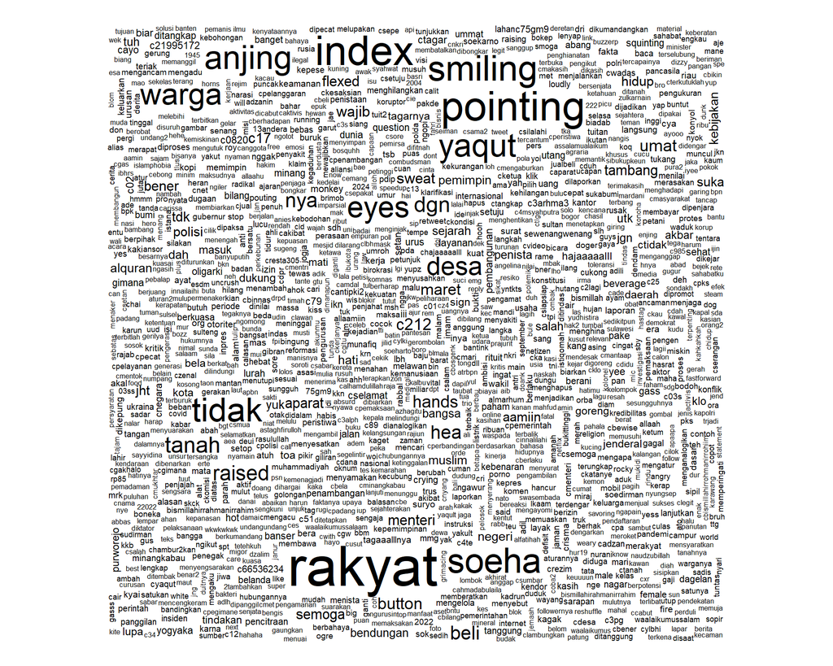

```r
library(wordcloud)

sudah_chr <- as.character(to_cloud_buzzer)
set.seed(100)
cloud_buzzer <- wordcloud(sudah_chr)
```

```r
cloud_buzzer
```

### Wordlcoud Buzzer: Analisis

Berdasarkan wordcloud, kita dapat melihat bahwa Buzzer lebih banyak menggaungkan hal-hal yang bersifat politik, pemerintahan, sara, dengan narasi-narasi negatif terhadap suatu topik. Kita nantinya dapat melihat cara kerja model dengan berpedoman pada hasil visualisasi wordcloud ini.

### Menyiapkan data untuk training model (1):

disimpan pada object `buzzer_clean`

```r
tes_list <- list(
  text_all = tes,
  label = buzzer$Label
)

buzzer_clean <- as_tibble(tes_list) %>%
  drop_na()

tail(buzzer_clean,5)
```

| text_all | label |
| --- | --- |
| mentri anjing | 0 |
| selamat memperingati isra miraj rajab h semoga kita selalu mendapat hidayah dari allaah swt agar lebih istiqomah berada di jalan kebenaran aamiin yaa rabbal allaamiin | 0 |
| bismillah | 0 |
| tangkap yaqut | 0 |
| pecat yaqut | 0 |

## Mengambil data dengan tweet “Personal Statement”

```r
personal <- aksata_enc %>%
  group_by(Label) %>%
  filter(Label == 2)

cleansing_personal <- as.character(personal$full_text)
cleansing_personal[1:10]
```

```
#>  [1] "CS: Pastiian HPnya masih ada pulsa ya Pak.\n\nOrang kaya beneran✅:\nTenang mba, pascabayar kok\n\nOrang kaya jadi2an⛔️:\n*ngamuk di twitter sambil pamer harta* https://t.co/U46xI8jnQV"
#>  [2] "Mau hp lo iPhone berlapis emas juga kalau gak ada pulsa ya gak bisa masuk kode OTP. Bener kata costumer service, emang itu sistemnya, dia gak sedang merendahkan lo sebagai orang kaya yg punya mobil harga stengah M. https://t.co/59jWGtvwRb"
#>  [3] "@jaydiristui @DRespati3 \"you can buy stuff, but you cannot buy class\" -aming"
#>  [4] "Tp rumah lo jelek bgt bang.👌 https://t.co/7jxXCwBgOy https://t.co/ZBX7jg4CAK"
#>  [5] "@afrkml @DRespati3 Bacain replyannya ners, dia ga seneng cara penyampainnya. Mungkin harapan dia gini kali ya.\n\"Yang mulia baginda nasabah kami? Sudikah kiranya yang mulia baginda memastikan dlm handphone iphonenya yang keluaran terbaru paling mahal terdapat pulsa?\""
#>  [6] "@DRespati3 Jangan2 mobil yg setengah M juga jarang dibawa kemari menghindari biar gak tersinggunh 😪😪😪 https://t.co/LKgP0184Dk"
#>  [7] "@DRespati3 10 things money can’t buy:\n1. Manners\n2. Morals\n3. Respect\n4. Character\n5. Common sense\n6. Trust\n7. Patience\n8. Class\n9. Integrity\n10. Love"
#>  [8] "@Annezui1 @DRespati3 Kelumpuhan yang dialaminya sejak menderita penyakit meningitis hidrosefalus, menimbulkan nyeri yang luar biasa. Tapi Devi tidak menyerah.\n\n#orangbaik, mari bantu berikan semangat untuk Devi dan berdonasi 🙏\nhttps://t.co/iucxwGrurX"
#>  [9] "@DRespati3 Gua pikir Anda sedang bercanda, rupanya emg benar2 tersinggung. Kok bs tersinggung ya? Itu kan komunikasi yg penting utk mengonfirmasi ada pulsa atau tidak karena prosedur urus m-banking memang pakai pulsa utk SMS. Gak ada hubungannya sama IPHONE apalagi agenda pamermu itu!!! 😩"
#> [10] "@DRespati3 It’s just joke https://t.co/CyoiZ0Ss8w"
```

```r
cleansing_personal <- replace_emoji(cleansing_personal) # replace emoji
cleansing_personal <- replace_hash(cleansing_personal) # replace hashtags
cleansing_personal <- replace_html(cleansing_personal, symbol = FALSE) # replace HTML Markups
cleansing_personal <- replace_number(cleansing_personal, remove = TRUE) # replace number
cleansing_personal <- replace_url(cleansing_personal, replacement = " ") # replace all http tag

cleansing_personal <- gsub( ":"," ", cleansing_personal)
cleansing_personal <- gsub( "\n"," ", cleansing_personal)
cleansing_personal <- gsub( "^@[A-Za-z]+|.+ @[A-Za-z]+" ," ", cleansing_personal)
cleansing_personal <- gsub( "@([^@ ]+){5,}" ," ", cleansing_personal)
cleansing_personal <- gsub( "^([^@]*@){5,}[^@]*$" ," ", cleansing_personal)
cleansing_personal <- removePunctuation(cleansing_personal)

# cleansing2 <- gsub( "relieved face"," ", cleansing2)
# cleansing2 <- gsub( "winking face with tongue"," ", cleansing2)
# cleansing2 <- gsub( "face"," ", cleansing2)
# cleansing2 <- gsub( "rt"," ", cleansing2)
# cleansing2 <- gsub( "oii"," ", cleansing2)
cleansing_personal <- tolower(cleansing_personal)
cleansing_personal <- gsub( "pak marsani"," ", cleansing_personal)
cleansing_personal <- gsub( "steno ricardo"," ", cleansing_personal)
cleansing_personal <- gsub( "mawar afi"," ", cleansing_personal)
cleansing_personal <- gsub( "3"," ", cleansing_personal)
```

```r
cleansing_personal[1:10]
```

```
#>  [1] "cs  pastiian hpnya masih ada pulsa ya pak orang kaya beneran white heavy check mark   tenang mba pascabayar kok orang kaya jadi2an no entry      ngamuk di twitter sambil pamer harta  "
#>  [2] "mau hp lo iphone berlapis emas juga kalau gak ada pulsa ya gak bisa masuk kode otp bener kata costumer service emang itu sistemnya dia gak sedang merendahkan lo sebagai orang kaya yg punya mobil harga stengah m  "
#>  [3] "   you can buy stuff but you cannot buy class aming"
#>  [4] "tp rumah lo jelek bgt bang ok hand    "
#>  [5] "   bacain replyannya ners dia ga seneng cara penyampainnya mungkin harapan dia gini kali ya yang mulia baginda nasabah kami sudikah kiranya yang mulia baginda memastikan dlm handphone iphonenya yang keluaran terbaru paling mahal terdapat pulsa"
#>  [6] "   jangan2 mobil yg setengah m juga jarang dibawa kemari menghindari biar gak tersinggunh sleepy face sleepy face sleepy face  "
#>  [7] "    things money can   t buy  1 manners 2 morals   respect 4 character 5 common sense 6 trust 7 patience 8 class 9 integrity 10 love"
#>  [8] "   kelumpuhan yang dialaminya sejak menderita penyakit meningitis hidrosefalus menimbulkan nyeri yang luar biasa tapi devi tidak menyerah         mari bantu berikan semangat untuk devi dan berdonasi folded hands  "
#>  [9] "   gua pikir anda sedang bercanda rupanya emg benar2 tersinggung kok bs tersinggung ya itu kan komunikasi yg penting utk mengonfirmasi ada pulsa atau tidak karena prosedur urus mbanking memang pakai pulsa utk sms gak ada hubungannya sama iphone apalagi agenda pamermu itu weary face "
#> [10] "   it   s just joke  "
```

### Final Wordcloud: Personal

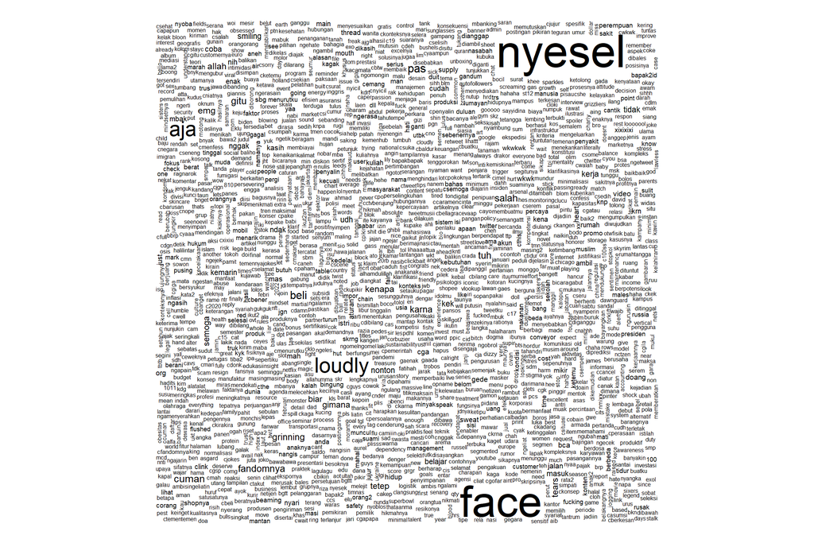

```r
to_cloud_personal <- tokenize_words(cleansing_personal, stopwords = unfaedah_words)

sudah_chr_pers <- as.character(to_cloud_personal)
set.seed(100)

cloud_personal <- wordcloud(sudah_chr_pers)
```

```r
cloud_personal
```

### Menyiapkan Data untuk Training model (2):

Disimpan pada object `personal_clean`

```r
personal_list <- list(
  text_all = cleansing_personal,
  label = personal$Label
)

personal_clean <- as_tibble(personal_list) %>%
  drop_na()

tail(personal_clean, 5)
```

| text_all | label |
| --- | --- |
| kolom reply quote sudah tersedia | 2 |
| eh ini yang kasus kemarin yang rame itu ya | 2 |
| semangat kak terima kasih sudah berani doa kami memeluk erat | 2 |
| kak syerin sending virtual hug semangat red heart | 2 |
| yaallah semangattt syerin | 2 |

## Mengambil data dari tweet “Media”

```r
media <- aksata_enc %>%
  group_by(Label) %>%
  filter(Label == 1)

cleansing_media <- as.character(media$full_text)
cleansing_media[1]
```

```
#> [1] "Akustik Lagu Sunda Dalam Rangka Menghibur Anak Yatim, Kolaborasi antara ... https://t.co/BdFhd1Pu9F via @YouTube"
```

```r
cleansing_media <- replace_emoji(cleansing_media) # replace emoji
cleansing_media <- replace_hash(cleansing_media) # replace hashtags
cleansing_media <- replace_html(cleansing_media, symbol = FALSE) # replace HTML Markups
cleansing_media <- replace_number(cleansing_media, remove = TRUE) # replace number
cleansing_media <- replace_url(cleansing_media, replacement = " ") # replace all http tag

cleansing_media <- gsub( ":"," ", cleansing_media)
cleansing_media <- gsub( "\n"," ", cleansing_media)
# cleansing3 <- gsub( "^@[A-Za-z]+|.+ @[A-Za-z]+" ," ", cleansing3)
# cleansing3 <- gsub( "@([^@ ]+){5,}" ," ", cleansing3)
# cleansing3 <- gsub( "^([^@]*@){5,}[^@]*$" ," ", cleansing3)
cleansing_media <- removePunctuation(cleansing_media)

# cleansing2 <- gsub( "relieved face"," ", cleansing2)
# cleansing2 <- gsub( "winking face with tongue"," ", cleansing2)
# cleansing2 <- gsub( "face"," ", cleansing2)
# cleansing2 <- gsub( "rt"," ", cleansing2)
# cleansing2 <- gsub( "oii"," ", cleansing2)
cleansing_media <- tolower(cleansing_media)
# cleansing3 <- gsub( "pak marsani"," ", cleansing3)
cleansing_media <- gsub( "viral"," ", cleansing_media)
cleansing_media <- gsub( "via youtube"," ", cleansing_media)
cleansing_media <- gsub( "intipseleb"," ", cleansing_media)
```

```r
cleansing_media[2050:2060]
```

```
#>  [1] "kpk gelontorkan nyaris rp1 miliar untuk sms blast ingatkan setor lhkpn  "
#>  [2] "airlangga blakblakan soal jht dan jkp  "
#>  [3] "tim konsesi motogp adalah tim pabrikan yang kurang berprestasi atau gagal meraih podium sepanjang satu musim apa saja keuntungan yang diperoleh tim konsesi simak selengkapnya di edisi terbaru       "
#>  [4] "foto  susah dapat jodoh partai komunis china jadi mak comblang  "
#>  [5] "tahanan kasus narkoba kabur dari rutan sampang  "
#>  [6] "ratusan aparat diterjunkan amankan bentrok di tengah hutan maluku  "
#>  [7] "menkes  indonesia berada di puncak kasus kematian covid19  "
#>  [8] "happy salma hingga kamila andini mejeng di berlinale  "
#>  [9] "wfo ppkm level  dilonggarkan jadi  persen  "
#> [10] "sejarah saudi ramaikan valentine berawal dari dekrit pangeran mbs  "
#> [11] "tes motogp mandalika  alex marquez ubah  kali setelan motor  "
```

### Final Wordcloud: Media

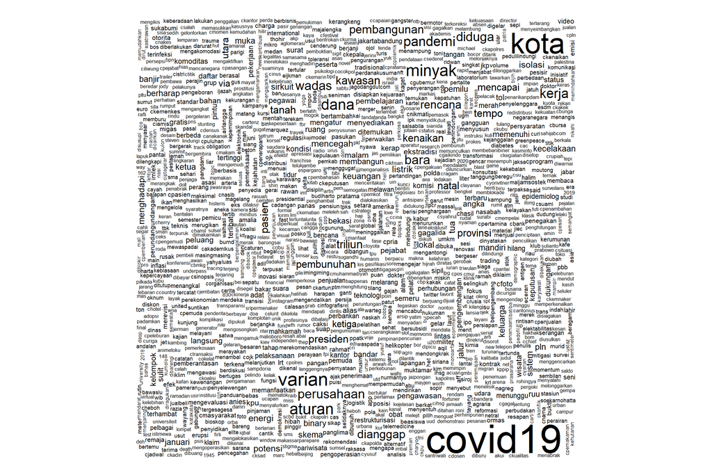

```r
to_media_personal <- tokenize_words(cleansing_media, stopwords = unfaedah_words)

sudah_chr_media <- as.character(to_media_personal)

set.seed(100)

media_personal <- wordcloud(sudah_chr_media)
```

```r
media_personal
```

### Menyiapkan Data untuk Training model (2):

Disimpan pada object `media_clean`

```r
media_list <- list(
  text_all = cleansing_media,
  label = media$Label
)

media_clean <- as_tibble(media_list)

tail(media_clean, 5)
```

| text_all | label |
| --- | --- |
| indonesia harus menciptakan masyarakan yang inovatif berbasis ilmu pengetahuan dan teknologi | 1 |
| penghargaan diberikan oleh bank sentral kepada shopeepay sebagai penyedia jasa pembayaran qris nonbank terbaik 2021 | 1 |
| menurut kantar market research sebanyak persen alumnus menjadi wirausaha semangat kewirausahaan itu telah dibangun melalui ekosistem di universitas prasetiya mulya | 1 |
| pemerintah sepertinya tak mau kehilangan momentum menggelar pembelajaran tatap muka saat kasus covid19 melandai simak hanya di facebook koran tempo dan instagram korantempodigital | 1 |
| mahfud md menyatakan pemerintah akan menjalankan pendekatan nonmiliter untuk menyelesaikan konflik papua panglima tni jenderal andika perkasa akan mengunjungi papua pada pekan ini tpnpbopm tak percaya… | 1 |

# Mengumpulkan Cleaned Dataset

```r
train_ready <- rbind(buzzer_clean, personal_clean, media_clean) %>%
  drop_na()
```

## Menyimpan data ke file internal

```r
# saveRDS(train_ready, file = "datatrain_clean.rds")
```

# Training Model

## Model 1: LSTM (Long Short Term Memory) using Tensorflow

```r
data <- read_rds("datatrain_clean.rds")
head(data,10)
```

| text_all | label |
| --- | --- |
| catet | 0 |
|  | 0 |
| proyek oligarki meminjam tangan penguasaan telah merampas hak rakyat bpn menjadi ma ir proyek pembangunan waduk bener | 0 |
| kau siapkan karpet merah para pemburu rente yang bergentayangan kau mudahkan dan kau buka lebar semua jalan bahkan hak hidup pekerja pun kau abaikan | 0 |
| ketakutan yg kau tebarkan intimidasi yg kau hujamkan pada setiap mereka yg berseberangan menjadi berbalik bak senjata makan tuan kekesalankesakitan rasa diremehkan disepelekandilupakan dan dihinakan m… | 0 |
| ya allah | 0 |
| ada bau busuk | 0 |
| fadli zon sebenarnya pembangunan ini untuk siapa | 0 |
| hidup nu hidup rakyat indonesia hidup warga wadas | 0 |
| hanya terjadi di 62 rakyat pemilik sah atas tanah diusir dengan dengan cara cara yang tidak berprikemanusiaan | 0 |

### Menghilangkan missing values pada dataset

```r
# library(dplyr)
data <- data %>%
   na.omit() %>%
   mutate(label = as.factor(label))
glimpse(data)
```

```
#> Rows: 14,977
#> Columns: 2
#> $ text_all <chr> "catet      ", "       ", "proyek oligarki meminjam tangan pe~
#> $ label    <fct> 0, 0, 0, 0, 0, 0, 0, 0, 0, 0, 0, 0, 0, 0, 0, 0, 0, 0, 0, 0, 0~
```

### Inisialisasi conda env dan package `keras`

```r
library(keras)
use_condaenv("r-tensorflow329")
```

### Menyiapkan Tokenizer

```r
num_words <- 2000 # proporsi sekitar 7 persen dari total unique words, mengikuti contoh di algotech

# prepare for tokenizers
tokenize <- keras::text_tokenizer(num_words = num_words,
                             lower = TRUE) %>%
   keras::fit_text_tokenizer(as.character(data$text_all))

paste("number of unique words:", length(tokenize$word_counts))
```

```
#> [1] "number of unique words: 24992"
```

```r
tokenize$word_index[100:150]
```

```
#> $setelah
#> [1] 100
#>
#> $ibu
#> [1] 101
#>
#> $para
#> [1] 102
#>
#> $lain
#> [1] 103
#>
#> $rumah
#> [1] 104
#>
#> $sendiri
#> [1] 105
#>
#> $hanya
#> [1] 106
#>
#> $soal
#> [1] 107
#>
#> $nya
#> [1] 108
#>
#> $hukum
#> [1] 109
#>
#> $tau
#> [1] 110
#>
#> $index
#> [1] 111
#>
#> $pointing
#> [1] 112
#>
#> $adalah
```

[output cut: 97 more lines]

```
#>
#> $backhand
#> [1] 146
#>
#> $semoga
#> [1] 147
#>
#> $allah
#> [1] 148
#>
#> $suara
#> [1] 149
#>
#> $rp
#> [1] 150
```

### Menyiapkan data untuk Cross Validation

```r
to_split <- data %>%
   mutate(label = as.numeric(label),
          label = label - 1)
head(to_split)
```

| text_all | label |
| --- | --- |
| catet | 0 |
|  | 0 |
| proyek oligarki meminjam tangan penguasaan telah merampas hak rakyat bpn menjadi ma ir proyek pembangunan waduk bener | 0 |
| kau siapkan karpet merah para pemburu rente yang bergentayangan kau mudahkan dan kau buka lebar semua jalan bahkan hak hidup pekerja pun kau abaikan | 0 |
| ketakutan yg kau tebarkan intimidasi yg kau hujamkan pada setiap mereka yg berseberangan menjadi berbalik bak senjata makan tuan kekesalankesakitan rasa diremehkan disepelekandilupakan dan dihinakan m… | 0 |
| ya allah | 0 |

```r
set.seed(100)
rows <- sample(nrow(to_split))

split <- to_split[rows, ]

split[200:210,2]
```

| label |
| --- |
| 0 |
| 1 |
| 2 |
| 1 |
| 0 |
| 1 |
| 2 |
| 0 |
| 2 |
| 0 |

[output cut: 1 more lines]

Data sudah teracak, dilihat melalui label yang sudah tidak berurutan.

### Memeriksa proporsi target variabel

```r
table(split$label) %>%
   prop.table()
```

```
#>
#>         0         1         2
#> 0.3338452 0.3338452 0.3323095
```

### Cross Validation

```r
library(rsample)

set.seed(100)
intrain <- initial_split(data = to_split, prop = 0.8, strata = "label")

data_train <- training(intrain)
data_val <- testing(intrain)
```

### Inisialisasi panjang karakter maksimal dalam tweet

```r
library(stringr)
maxlen <- max(str_count(to_split$text_all, "\\w+")) + 1
paste("maximum length of words in data:", maxlen)
```

```
#> [1] "maximum length of words in data: 105"
```

### Menyiapkan target dan prediktor

```r
# prepare x

data_train_x <- texts_to_sequences(tokenize, data_train$text_all) %>%
  pad_sequences(maxlen = maxlen)

data_val_x <- texts_to_sequences(tokenize, data_val$text_all) %>%
  pad_sequences(maxlen = maxlen)


# prepare y
data_train_y <- to_categorical(data_train$label, num_classes = 3)#, num_classes = 3)
data_val_y <- to_categorical(data_val$label, num_classes = 3)
```

### Inisialisasi `keras_model_sequential`

```r
model <- keras_model_sequential()
```

### Arsitektur Model LSTM

embedding –> dropout –> LSTM –> dense

```r
tensorflow::tf$random$set_seed(100)
# model
model %>%
  # layer input
  layer_embedding(
    name = "input",
    input_dim = num_words,
    input_length = maxlen,
    output_dim = 32,
    embeddings_initializer = initializer_random_uniform(minval = -0.05, maxval = 0.05, seed = 2)
  ) %>%
  # layer dropout
  layer_dropout(
    name = "embedding_dropout",
    rate = 0.3
  ) %>%
  # layer lstm 1
  layer_lstm(
    name = "lstm1",
    units = 256,
    dropout = 0.2,
    recurrent_dropout = 0.2,
    return_sequences = FALSE,
    recurrent_initializer = initializer_random_uniform(minval = -0.05, maxval = 0.05, seed = 2),
    kernel_initializer = initializer_random_uniform(minval = -0.05, maxval = 0.05, seed = 2)
  ) %>%
  # layer output
  layer_dense(
    name = "output",
    units = 3,
    activation = "softmax",
    kernel_initializer = initializer_random_uniform(minval = -0.05, maxval = 0.05, seed = 2)
  )
```

### Compiling Model

```r
# compile the model
model %>% compile(
  optimizer = "adam",
  metrics = "accuracy",
  loss = "categorical_crossentropy"
)

# model summary
summary(model)
```

```
#> Model: "sequential"
#> ________________________________________________________________________________
#> Layer (type)                        Output Shape                    Param #
#> ================================================================================
#> input (Embedding)                   (None, 105, 32)                 64000
#> ________________________________________________________________________________
#> embedding_dropout (Dropout)         (None, 105, 32)                 0
#> ________________________________________________________________________________
#> lstm1 (LSTM)                        (None, 256)                     295936
#> ________________________________________________________________________________
#> output (Dense)                      (None, 3)                       771
#> ================================================================================
#> Total params: 360,707
#> Trainable params: 360,707
#> Non-trainable params: 0
#> ________________________________________________________________________________
```

### Model Fitting

Dengan `epoch` = 10 dan `batch_size` = 512

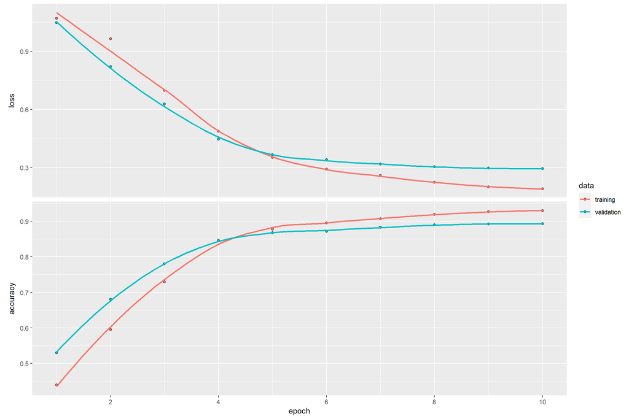

```r
epochs <- 10
batch_size <- 512

# fit the model
history <- model %>% fit(
  data_train_x, data_train_y,
  batch_size = batch_size,
  epochs = epochs,
  verbose = 1,
  validation_data = list(
    data_val_x, data_val_y
  )
)

# history plot
plot(history)
```

### Predict data validation

```r
# predict on train
options(scipen = 123)
data_train_pred <- model %>%
  predict_classes(data_train_x) %>%
  as.vector()

# predict on val
data_val_pred <- model %>%
  predict_classes(data_val_x) %>%
  as.vector()
```

## Model Evaluation: LSTM with Tensorflow

```r
# accuracy on data train
library(yardstick)
accuracy_vec(
 truth = factor(data_train$label,labels = c("buzzer", "media", "personal")),
 estimate = factor(data_train_pred, labels = c("buzzer", "media", "personal"))
)
```

```
#> [1] 0.940823
```

### Akurasi pada data validation: 89% (acuan overfitting: lebih dari 5 persen)

```r
# accuracy on data validation
accuracy_vec(
 truth = factor(data_val$label,labels = c("buzzer", "media", "personal")),
 estimate = factor(data_val_pred, labels = c("buzzer", "media", "personal"))
)
```

```
#> [1] 0.8931909
```

### Sensitivity data validation: 89%

```r
# sensitivity on data validation
sensitivity_vec(
 truth = factor(data_val$label,labels = c("buzzer", "media", "personal")),
 estimate = factor(data_val_pred, labels = c("buzzer", "media", "personal"))
)
```

```
#> [1] 0.893162
```

### Specificity data validation: 94%

```r
specificity_vec(
  truth = factor(data_val$label, labels = c("buzzer", "media", "personal")),
  estimate = factor(data_val_pred, labels = c("buzzer", "media", "personal"))
)
```

```
#> [1] 0.9465965
```

```r
# precision on data validation

ppv_vec(
   truth = factor(data_val$label, labels = c("buzzer", "media", "personal")),
   estimate = factor(data_val_pred, labels = c("buzzer", "media", "personal"))
)
```

```
#> [1] 0.8933404
```

## Menguji Performa Model dengan data baru dari Twitter

Saya memiliki sebuah data twitter search query yang didominasi oleh personal statement. Saya ingin melihat bagaimana mesin dapat memprediksi bahwa teks-teks tersebut ditulis oleh perseorangan.

```r
test <- read_rds("geprek bensu-AKSATA.rds")
```

```r
test_5000 <- test %>%
  select(full_text) %>%
  mutate(label = NA) %>%
  distinct() %>%
  head(5000)

nrow(test_5000)
```

```
#> [1] 1776
```

## Model 1: Predict on Datatest

```r
data_test_x <- texts_to_sequences(tokenize, test_5000$full_text) %>%
  pad_sequences(maxlen = maxlen)
```

```r
# predict on data test
data_test_pred <- model %>%
  predict_classes(data_test_x) %>%
  as.vector()


# create submission data

submission <- test_5000 %>%
  mutate(label = data_test_pred)


inspect_buzzer_pred <- submission %>%
  filter(label == 0)

inspect_personal_pred <- submission %>%
  filter(label == 2)

inspect_media_pred <- submission %>%
  filter(label == 1)


inspect_media_pred
```

| full_text | label |
| --- | --- |
| Jordi Onsu mengklaim Geprek Bensu sebagai ayam Indonesia pertama yang tampil di Paris Fashion Week. Netizen pun auto nyinyir saat membaca unggahan tersebut. https://t.co/67dqtIf72o | 1 |
| RT @haipep: tetangga aq punya afc alias aceh fried chicken sedikit iri dengan geprek bensu yang ke paris fashion week aq bilang sabar kita… | 1 |
| RT @ngeroompi: Geprek Bensu, you are insulting our intelligence and embarrassing our nation. https://t.co/QUqcDL7tzf | 1 |
| RT @warsawconcerto: geprek bensu at paris fashion week https://t.co/EltEde0A0g | 1 |
| AS Kirim Rudal Patriot Ke Polandia, Tangkal Ancaman Rusia https://t.co/sqzeVbW48K \n\n#SongHyeKyo #LetsMakeSomeNoice GEPREK BENSU Dita Karang Crazy Rich Quotex Jaemin | 1 |
| Penumpang KRL Bisa Duduk Tanpa Jarak Mulai Hari Ini https://t.co/uxpfs5dtsD \n\n#SongHyeKyo #LetsMakeSomeNoice GEPREK BENSU Dita Karang Crazy Rich Quotex Jaemin | 1 |
| Penumpang Domestik Tak Perlu Hasil PCR Dan Antigen Mulai Hari Ini! https://t.co/8QxRK2hAo8 \n\n#SongHyeKyo #LetsMakeSomeNoice GEPREK BENSU Dita Karang Crazy Rich Quotex Jaemin | 1 |
| Menjelang Endemi, Java Jazz Kembali Hadir Di Tahun Ini! https://t.co/vVyGxZRKbM \n\n#SongHyeKyo #LetsMakeSomeNoice GEPREK BENSU Dita Karang Crazy Rich Quotex Jaemin | 1 |
| Firli Bahuri Akan Dilaporkan ke Dewas KPK soal Hymne Karangan Istri https://t.co/VQWL5JhSik \n\n#SongHyeKyo #LetsMakeSomeNoice GEPREK BENSU Dita Karang Crazy Rich Quotex Jaemin | 1 |
| Top 3 Sports: 2 Pesan Roman Abramovich Jelang Jual Chelsea, Liverpool Kalah https://t.co/nsFc7AYNTA \n\n#SongHyeKyo #LetsMakeSomeNoice GEPREK BENSU Dita Karang Crazy Rich Quotex Jaemin | 1 |

[output cut: 259 more lines]

```r
# to_submit <- ifelse(submission$bully == 1, "yes", "no")
#
# submission <- datatest %>%
#   mutate(bully = to_submit)
```

```r
inspect_buzzer_pred
```

| full_text | label |
| --- | --- |
| Ownernya tukang ngibul\nAdmin brandnya tukang pansos\n\nTAU MALU DIKIT LAH WOY GEPREK BENSU https://t.co/yONq77JFPC | 0 |
| RT @hanifsulthonii: forget about geprek bensu n those local brands who claimed to be a part of paris fashion week. here’s rizal rama, an In… | 0 |
| Subardi Minta Agar Pemilu Jangan Ditunda Maupun Dipercepat https://t.co/QSCwo9gqO5 \n\n#SongHyeKyo #LetsMakeSomeNoice GEPREK BENSU Dita Karang Crazy Rich Quotex Jaemin | 0 |
| Enakan geprek bensu atau i'am geprek bensu? | 0 |
| @wolipop Terlepas dr pro dan kontra iam geprek bensu adalah mknn pedas favorite saya | 0 |
| RT @SalmaFaatimah: Jangan peduli dgn apa yg dikatakn orang jika itu baik tetap laksanakan.\n\n_____________\nGEPREK BENSU\nRest In Peace\nSelena… | 0 |
| @prlzsp @kimeenotkime setuju kalo ini, mau i am geprek bensu sekalipun sambel nya ga ada yg pedes | 0 |
| @RYXKMJ promosi geprek bensu | 0 |
| #BONA #HAPPYSUGADAY #CiptaDamaiCartenz Geprek Bensu Ada GO Softex Pagiii Atasan Tulus Nasi Padang Grammy Est 1kg ELEVEN 100M VIEWS U TOO Wanda Hamidah Ernest Softex Paris Fashion Week Tomkins brimo KI… | 0 |
| @Calingg__ mendingan geprek bu made daripada bensu | 0 |

[output cut: 295 more lines]

```r
inspect_personal_pred
```

| full_text | label |
| --- | --- |
| RT @kodakgoldexp: YAKALI GEPREK BENSU DI PARIS FASHION WEEK ANJING WKWKWMWKWMWKWKWMWKWKWKWKWKWKWKKW KOMEDI BGT LU KIRA BAZAR RAMADHAN | 2 |
| eh gw pengen bikin vid edit haechan pake lagu geprek bensu siapa mau di tag https://t.co/qxvEJ0haIf | 2 |
| RT @belajarlagiHQ: Rame bahas Paris Fashion Week, ternyata brand Indo kayak geprek bensu dkk ngadain acara sendiri yg waktunya bareng sama… | 2 |
| RT @phloeme: forget about geprek bensu in paris heres an indonesian having his own stand at an exhibition in france (not paris not fashion… | 2 |
| RT @adnardn: Nah, sedangkan Geprek Bensu lewat Jordi Onsu dan abangnya Ruben Onsu, masih aja percaya diri bilang kalo Geprek Bensu tampil d… | 2 |
| RT @karirmuid: Ehhh...\nKalau pas interview kamu ditanya..\n"Kenapa perusahaan harus menerima kamu?"\n\nTau jawabannya... Simak yuuuk\n\nCrazy Ri… | 2 |
| RT @AjengFtmh_: Om Putin ngakak liatin lawakan si Zalenki \n---\nCrazy Rich\nSultan\nOlga\nGEPREK BENSU https://t.co/0wa3tsCMdJ | 2 |
| RT @adnardn: Abis lihat masalah "Paris Fashion Week"-nya Geprek Bensu yang lagi rame dan akhirnya ketemu missnya di mana.\n\nJadi, ada satu b… | 2 |
| Open vcs Beb\n~50K-30MENIT\n~100K-60MENIT\nCEK WA 085281657452\n#ONEPIECE1043 \nGEPREK BENSU\nDita Karang\n#SongHyeKyo \nOlga https://t.co/e3BplX5v7B | 2 |
| RT @bergman_esque: All this Geprek Bensu discourse is moving us from the one that should’ve deserved the exposure more…… Look at the slay w… | 2 |

[output cut: 1192 more lines]

Pada Model 1 (Long Short Term Memmory menggunakan Tensorflow), kita dapat melihat bahwa dari total entri data test sebanyak 1776 tweets, model dapat memprediksi 1153 tweets murni sebagai personal statement. Sedangkan, berbicara mengenai dataset, kita dapat melihat bahwa `test_5000` tidak sepenuhnya diisi oleh tweet perseorangan. Ada beberapa tweet yang betul-betul dikemukakan oleh Media, misalnya.

Sedangkan untuk class `buzzer` pada kasus ini, Mesin mengalami bias klasifikasi karena kelas buzzer pada data train lebih banyak mengandung kalimat bernada negatif. Sehingga ketika terdapat tweet perseorangan namun bernada negatif pula (pada data test), mesin mempelajarinya sebagai buzzer.